# ca2-supply-chain slides

[figure not shown]

presented by:

```
- Sunil PRAKASH
- Gaelan GU
- Abhilasha K
```

## Agenda

- Demand Forecasting
- Inventory Management
- Warehouse Optimization
- Network Planning
- Reverse Logistics

#### Demand Forecasting

[figure not shown]

### Background

- Important to forecast sales for business planning purposes
- Overestimation leads to surplus of goods and underestimation creates a potential stockout situation
- Forecasts are not always correct - but in Walmart's case, seasonality can easily be accounted for
- Net sales figures in millions extracted from Walmart's quarterly reports from FY 2010 to 2018

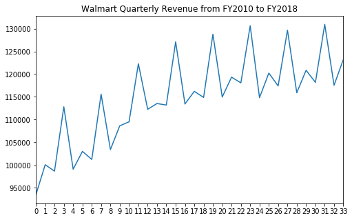

```
Increasing trend seems to occur within this time period
```

```python
ts.plot(figsize=(8,5), title='Walmart Quarterly Revenue from FY2010 to FY2018')
plt.xticks(range(0, 34, 1))
plt.show()
print("Increasing trend seems to occur within this time period")
```

- **Increasing** trend seems to occur within this time period
  - Begins to plateau around start of FY 2015
- **Strong** seasonality pattern due to expected consumer behaviour which happens throughout the year
  - e.g. Events in Q4 like Black Friday, Christmas and New Year's

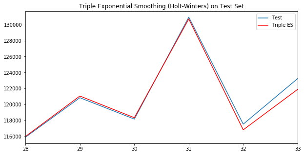

```python
test.plot(figsize=(10,5), label='Test', legend=True)
es3_test.plot(figsize=(10,5), color='r', label='Triple ES', legend=True)
plt.title('Triple Exponential Smoothing (Holt-Winters) on Test Set')
plt.show()
```

```python
%matplotlib inline

@interact
def forecast_stocks(period=4):
    es3_p = triple_exp_smoothing(ts, 4, 0.1, 0.5, 0.9, period)
    es3_p = pd.Series(es3_p)
    ts.plot(figsize=(10,5), color='b', label='actual', legend=True)
    es3_p[33:].plot(figsize=(10,5), color='r', label='predicted', legend=True)
    plt.xticks(range(0, 37, 1))
    plt.title("Forecasted Demand for Walmart's Next 4 Quarters")
    #plt.show()
```

### Warehouse and Inventory

Data Distribution

[figure not shown]

Economic order quantity (EOQ) is an equation for inventory that determines the ideal order quantity a company should purchase for its inventory given a set cost of ordering, demand rate and other variables. This is done to minimize variable inventory costs, and the formula takes into account storage, or holding, costs, ordering costs and shortage costs.

[figure not shown]

##### Economic Order Quantity Formula

$$ EOQ = \sqrt{\frac{2OD}{CI}}$$

- O = Ordering Costs
- D = Annual Demand rate
- C = Unit Costs
- I = Holding rate (% per year)

```python
@interact
def eoq_optimization(order=100,cost=10,interest=10):
    if order>0 and cost>0 and interest>0:
        EOQ = int(math.sqrt((2*order*annual_demand)/(cost*interest/100.)))
        print ("Economic Order Quantity is",EOQ)
    else:
        print("Values cannot be -ve")
```

The re-order point (ROP) is the level of inventory which triggers an action to replenish that particular inventory stock. It is a minimum amount of an item which a firm holds in stock, such that, when stock falls to this amount, the item must be reordered. It is normally calculated as the forecast usage during the replenishment lead time plus safety stock.

[figure not shown]

Reorder Point = Demand during lead-time + Safety Stock

[output not shown]

Demand during Lead Time

- Total requirement for an item in the lead time

  LTU = LT x Usage rate

Setting Safety Stock

- Lead time is not accurately known and demand cannot be predicted exactly
- Safety Stock (SS) is the product of the standard deviation over the lead time and the safety factor K

  Number of order/year (N) = Annual demand/EOQ

```python
N = annual_demand/EOQ
print "Therefore the number of order/year is {}".format(N)

P = ((1)*EOQ)/float(annual_demand)
print "Therefore the probability of stock shortage is {:.1%}".format(P)
```

```
Therefore the number of order/year is 52
Therefore the probability of stock shortage is 1.9%
```

From the **normal distribution** table

k = 2.0

Assuming standard deviation over lead time as

Assuming demand during lead time as

LTU = 1000

Hence

ROP = LTU + SS = 1000 + 600 = **1600** </small>

Warehouse Optimization

[figure not shown]

### BACKGROUND

##### Logical Constraints

- Products shipped from the dc to store must be >= 0
- The products shipped can not exceed the capacity of the dc and the number shipped should meet the demand of the store products_stored<= capacity  
  total_shipped >= demand a DC must be open to ship goods to store

##### Objective

To Minimize the Overall Operating Cost

Data

[figure not shown]

### SOLUTION

- the optimal solution was found using the gurobi optimization tools facity model
- the optimal operating cost was found to be $212700
- the operational cost was reduced by $12000
- DC 2 and 4 needs to be cost
- new optimal model is able to all store demands with 3 DC's

[figure not shown]

### Network and Route Planning

### Objective :

- To find shortest route to optimize the Utilization
- Shortest Route from to warehouse to all distribution centers was Found
- Distribution Center And WareHouse dataset Of USA
- Vehicle Routing Problem, Best possible route was found

[figure not shown]

- But ,in real life routing just not depends on the shortest route
- challenge is to find the most optimal route with given constraints
- which should increase the utilization of vehicle and thus serving the objective
- simulation to show process optimization

[figure not shown]

- shows scenarios like trucks from warehouse going to the Distribution centers
- waits till the time packing / unpacking is done then moves back to the warehouse
- then to maximize the utilization of vehicles in the route we run optimization model
- optimal no of trucks to be used in this route is 6 ,
- we are using 10, 4 vehicles can be used in other operations

[figure not shown]

[video not shown]

### Reverse Logistic

[figure not shown]

Optimal Route?

[figure not shown]

```python
@interact
def calculate_optimal_route(num_routes=3,depot=6,time_window=12):
    if num_routes>0 and (depot>-1 and depot<10) and time_window>0:
        main_routing(num_routes,depot,time_window)
```

Thank you ???(-_- )???

*"You Don't Know What You Don't Know"*